# Pilot Study - Measuring Trust in AI

Oliver Lack Data61 CSIRO

2022 - 2023

# Analyses

## Summary Statistics

### Group Count

#### **Group Count**

| Car | n1 | Virtual_Cell_Select | n2 | DataDoc(Hp LP) - Airline (HI LI) | n3 |
| --- | --- | --- | --- | --- | --- |
| HI | 20 | HI | 20 | HI | 20 |
| HP | 21 | HP | 21 | HP | 20 |
| LI | 20 | LI | 20 | LI | 21 |
| LP | 19 | LP | 19 | LP | 19 |

### Summary by Application

#### **Summary Statistics by Application**

| Score | AI_Application | Mean | SD | Median | Min | Max |
| --- | --- | --- | --- | --- | --- | --- |
| Risk | Car | 79.28 | 21.23 | 80.0 | 25 | 100 |
| Risk | Virtual Cell Select | 66.47 | 26.62 | 72.0 | 0 | 100 |
| Risk | DataDoc / Airline | 69.28 | 28.66 | 77.0 | 0 | 100 |
| Trust | Car | 3.25 | 1.84 | 3.0 | 1 | 7 |
| Trust | Virtual Cell Select | 3.66 | 1.83 | 4.0 | 1 | 7 |
| Trust | DataDoc / Airline | 3.36 | 2.07 | 4.0 | 1 | 7 |
| Performance | Car | 49.35 | 32.27 | 52.0 | 0 | 100 |
| Performance | Virtual Cell Select | 55.15 | 31.61 | 51.5 | 0 | 100 |
| Performance | DataDoc / Airline | 53.44 | 32.47 | 61.5 | 0 | 100 |
| Integrity | Car | 50.86 | 29.27 | 51.0 | 0 | 100 |
| Integrity | Virtual Cell Select | 50.74 | 30.94 | 51.0 | 0 | 100 |
| Integrity | DataDoc / Airline | 50.69 | 30.62 | 51.0 | 0 | 100 |

### Summary by Condition

#### **Summary Statistics by Condition**

| Score | AI_Application | Condition | Mean | SD | Median | Min | Max |
| --- | --- | --- | --- | --- | --- | --- | --- |
| Risk | Car | HP | 74.43 | 21.67 | 77.0 | 28 | 100 |
| Risk | Virtual Cell Select | HP | 50.62 | 23.63 | 50.0 | 9 | 100 |
| Risk | DataDoc / Airline | HP | 73.50 | 24.92 | 77.0 | 14 | 100 |
| Risk | Car | LP | 91.74 | 10.91 | 95.0 | 62 | 100 |
| Risk | Virtual Cell Select | LP | 86.84 | 14.01 | 91.0 | 52 | 100 |
| Risk | DataDoc / Airline | LP | 82.84 | 22.36 | 84.0 | 2 | 100 |
| Risk | Car | HI | 62.80 | 21.44 | 65.5 | 25 | 100 |
| Risk | Virtual Cell Select | HI | 49.55 | 24.02 | 54.5 | 0 | 79 |
| Risk | DataDoc / Airline | HI | 41.50 | 28.04 | 48.5 | 0 | 95 |
| Risk | Car | LI | 89.00 | 15.54 | 98.5 | 39 | 100 |
| Risk | Virtual Cell Select | LI | 80.70 | 19.68 | 83.0 | 35 | 100 |
| Risk | DataDoc / Airline | LI | 79.43 | 19.65 | 83.0 | 32 | 100 |
| Trust | Car | HP | 4.14 | 1.62 | 4.0 | 1 | 7 |
| Trust | Virtual Cell Select | HP | 5.33 | 1.02 | 5.0 | 3 | 7 |
| Trust | DataDoc / Airline | HP | 4.10 | 1.59 | 5.0 | 1 | 6 |
| Trust | Car | LP | 1.89 | 1.15 | 1.0 | 1 | 5 |
| Trust | Virtual Cell Select | LP | 2.42 | 1.35 | 2.0 | 1 | 6 |
| Trust | DataDoc / Airline | LP | 1.42 | 1.12 | 1.0 | 1 | 5 |
| Trust | Car | HI | 5.05 | 1.00 | 5.0 | 3 | 7 |
| Trust | Virtual Cell Select | HI | 4.70 | 1.22 | 5.0 | 1 | 6 |
| Trust | DataDoc / Airline | HI | 5.55 | 0.89 | 5.5 | 4 | 7 |
| Trust | Car | LI | 1.80 | 0.83 | 2.0 | 1 | 3 |
| Trust | Virtual Cell Select | LI | 2.05 | 1.05 | 2.0 | 1 | 4 |
| Trust | DataDoc / Airline | LI | 2.33 | 1.62 | 2.0 | 1 | 6 |
| Performance | Car | HP | 69.76 | 16.15 | 72.0 | 50 | 100 |
| Performance | Virtual Cell Select | HP | 80.57 | 14.19 | 82.0 | 50 | 100 |
| Performance | DataDoc / Airline | HP | 66.50 | 20.17 | 71.5 | 0 | 98 |
| Performance | Car | LP | 14.00 | 18.94 | 8.0 | 0 | 73 |
| Performance | Virtual Cell Select | LP | 24.53 | 23.37 | 24.0 | 0 | 76 |
| Performance | DataDoc / Airline | LP | 12.05 | 21.31 | 0.0 | 0 | 70 |
| Performance | Car | HI | 77.70 | 12.86 | 78.0 | 50 | 100 |
| Performance | Virtual Cell Select | HI | 75.50 | 17.98 | 76.0 | 45 | 100 |
| Performance | DataDoc / Airline | HI | 80.50 | 15.07 | 80.0 | 51 | 100 |
| Performance | Car | LI | 33.15 | 26.80 | 25.0 | 0 | 79 |
| Performance | Virtual Cell Select | LI | 37.20 | 25.96 | 41.5 | 0 | 100 |
| Performance | DataDoc / Airline | LI | 52.67 | 24.97 | 51.0 | 9 | 95 |
| Integrity | Car | HP | 64.67 | 17.16 | 57.0 | 35 | 100 |
| Integrity | Virtual Cell Select | HP | 73.52 | 22.56 | 77.0 | 8 | 100 |
| Integrity | DataDoc / Airline | HP | 66.90 | 18.88 | 74.0 | 10 | 97 |
| Integrity | Car | LP | 31.63 | 17.85 | 35.0 | 0 | 52 |
| Integrity | Virtual Cell Select | LP | 37.89 | 19.25 | 34.0 | 0 | 76 |
| Integrity | DataDoc / Airline | LP | 29.79 | 20.54 | 27.0 | 0 | 72 |
| Integrity | Car | HI | 80.55 | 15.94 | 81.5 | 50 | 100 |
| Integrity | Virtual Cell Select | HI | 73.25 | 18.37 | 75.5 | 21 | 100 |
| Integrity | DataDoc / Airline | HI | 76.85 | 16.42 | 78.0 | 51 | 100 |
| Integrity | Car | LI | 24.95 | 21.95 | 25.0 | 0 | 60 |
| Integrity | Virtual Cell Select | LI | 16.50 | 15.82 | 16.5 | 0 | 51 |
| Integrity | DataDoc / Airline | LI | 29.24 | 29.74 | 22.0 | 0 | 91 |

### Means

#### **Summary of Means Between Conditions**

**Performance**

| AI_Application | Score | Condition | Mean | Condition2 | Mean2 |
| --- | --- | --- | --- | --- | --- |
| Car | Performance | HP | 69.76 | LP | 14.00 |
| Virtual Cell Select | Performance | HP | 80.57 | LP | 24.53 |
| DataDoc | Performance | HP | 66.50 | LP | 12.05 |

**Integrity**

| AI_Application | Score | Condition | Mean | Condition2 | Mean2 |
| --- | --- | --- | --- | --- | --- |
| Car | Integrity | HI | 80.55 | LI | 24.95 |
| Virtual Cell Select | Integrity | HI | 73.25 | LI | 16.50 |
| Airline Profiling | Integrity | HI | 76.85 | LI | 29.24 |

## Violin/Box-Plot Visualization

### Risk

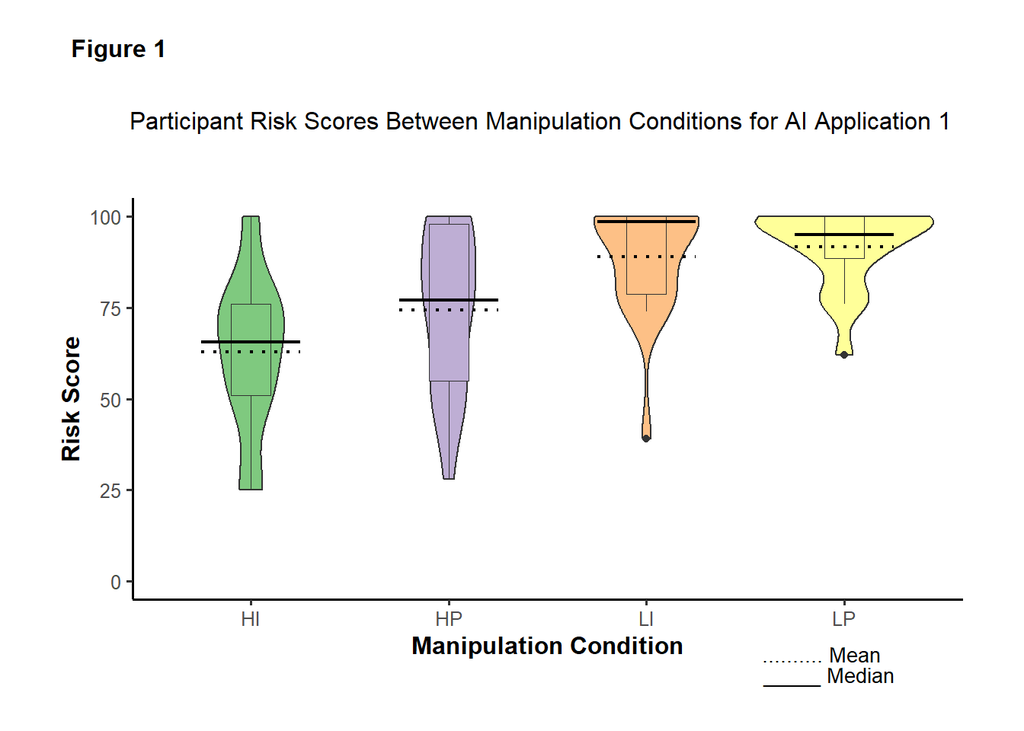

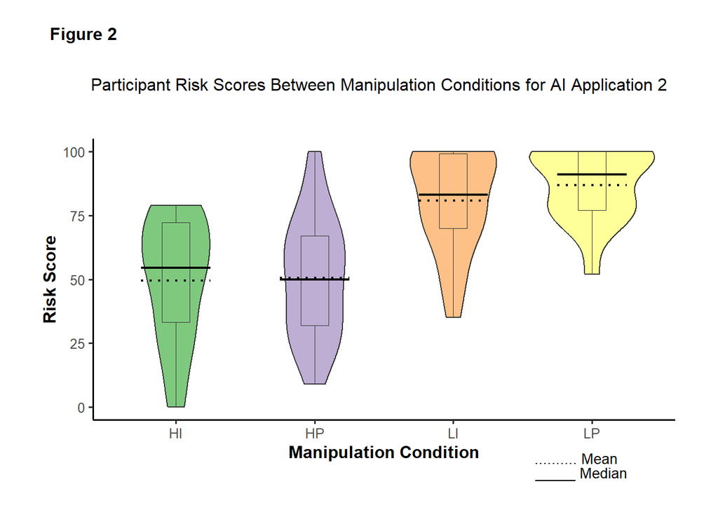

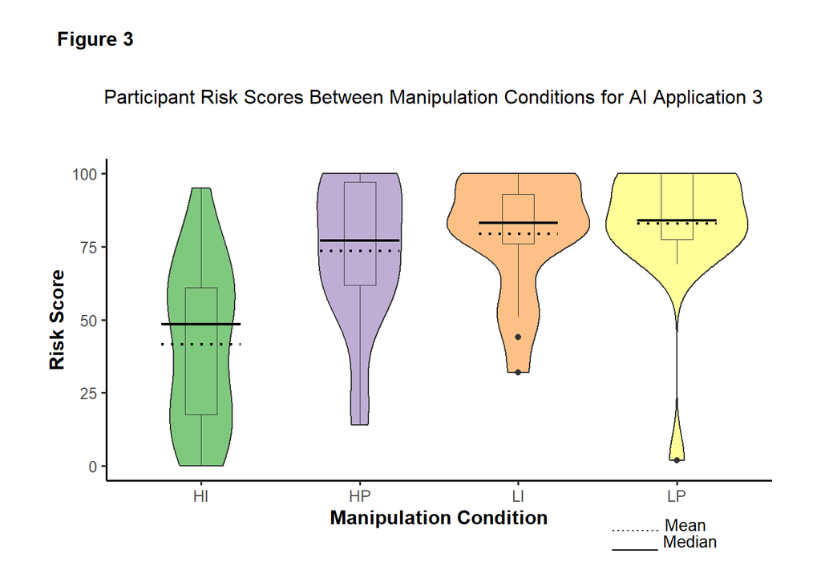

### Trust

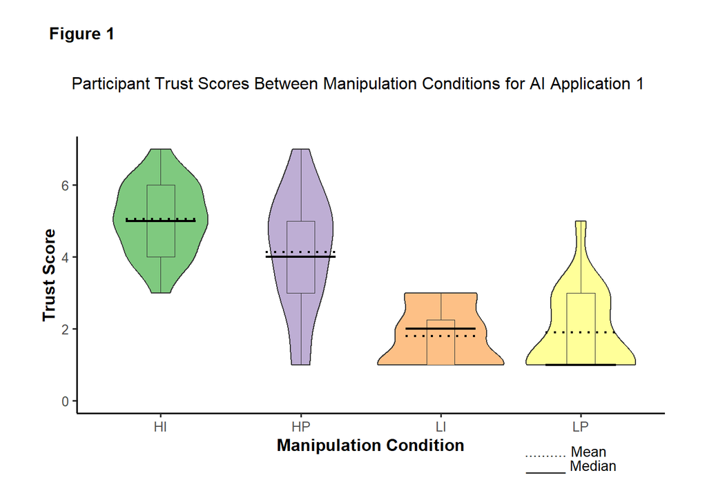

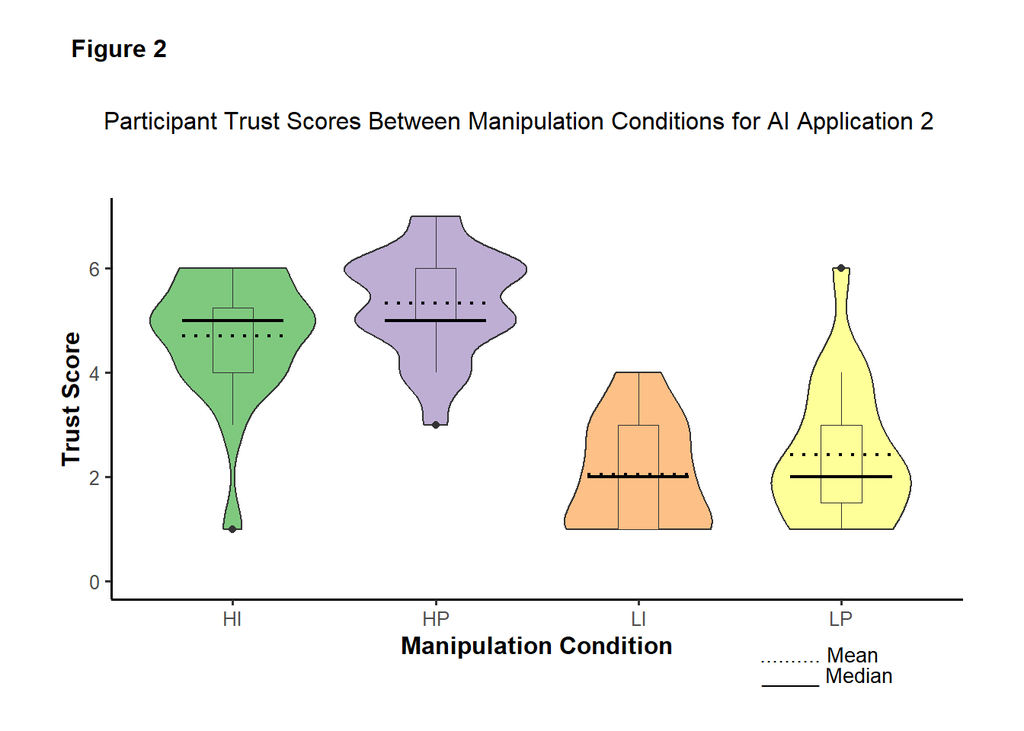

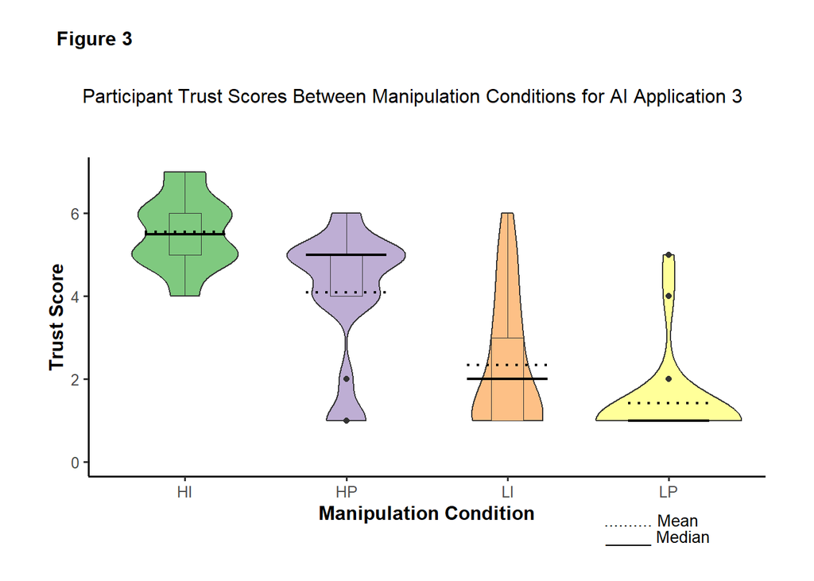

### Performance

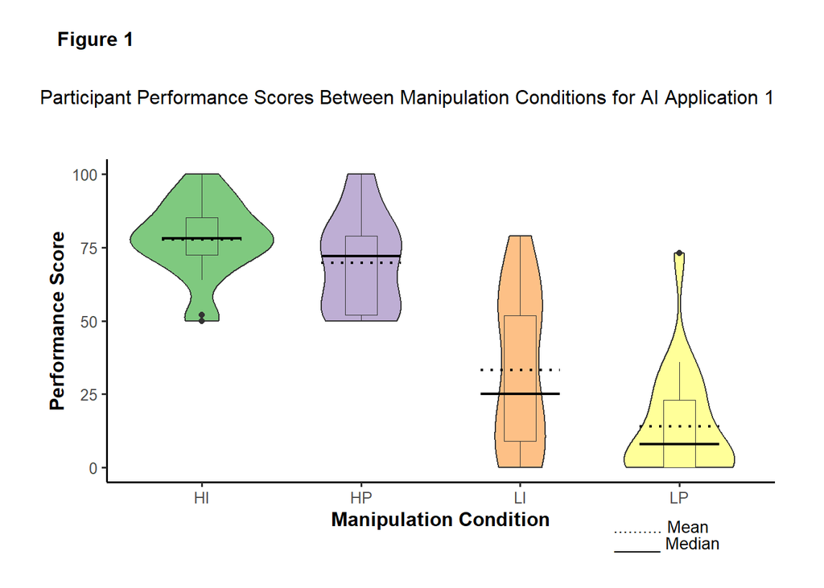

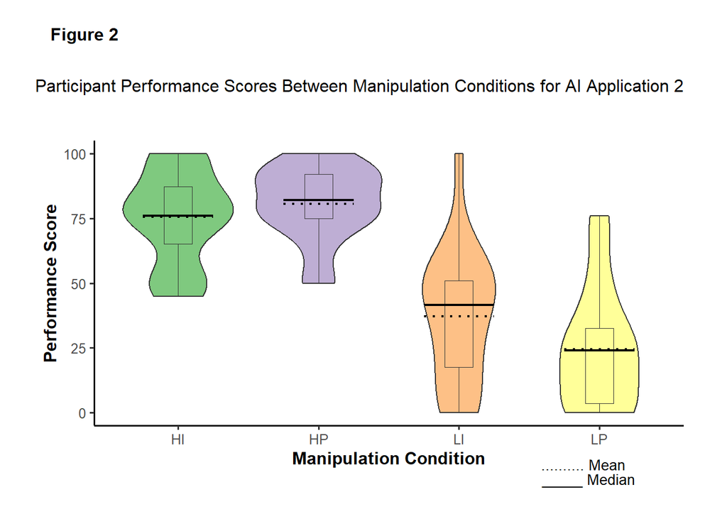

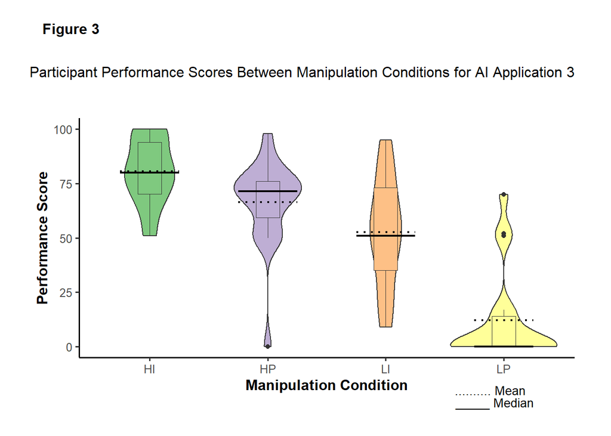

### Integrity

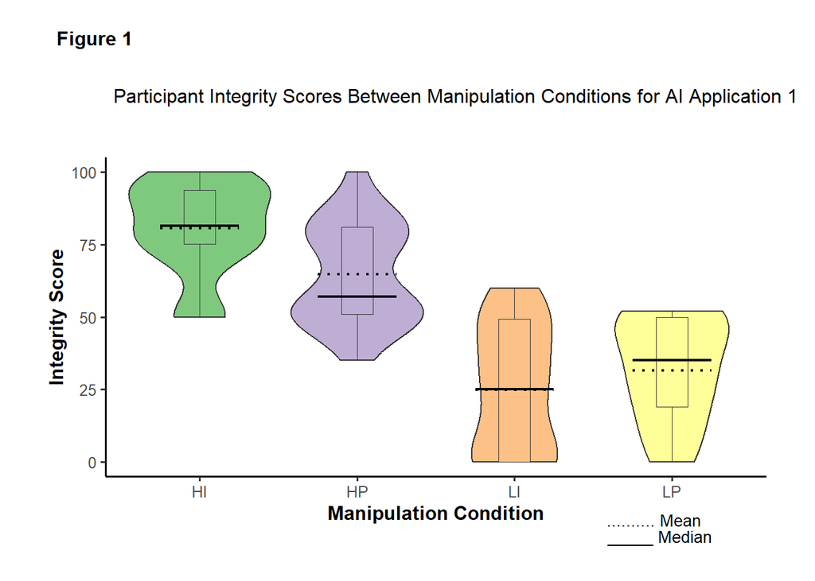

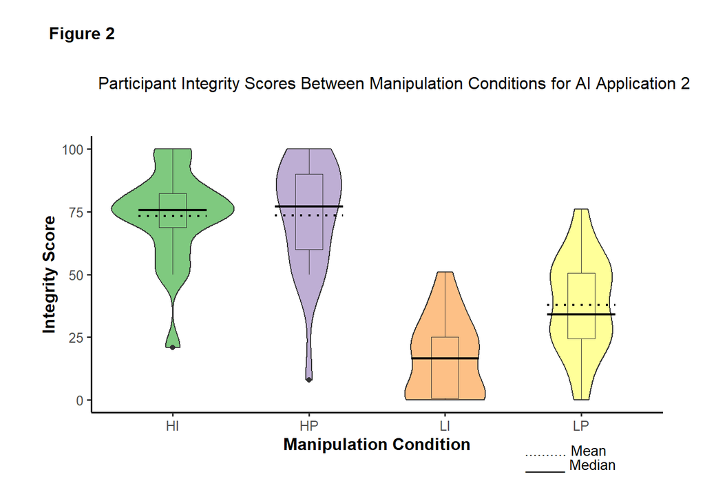

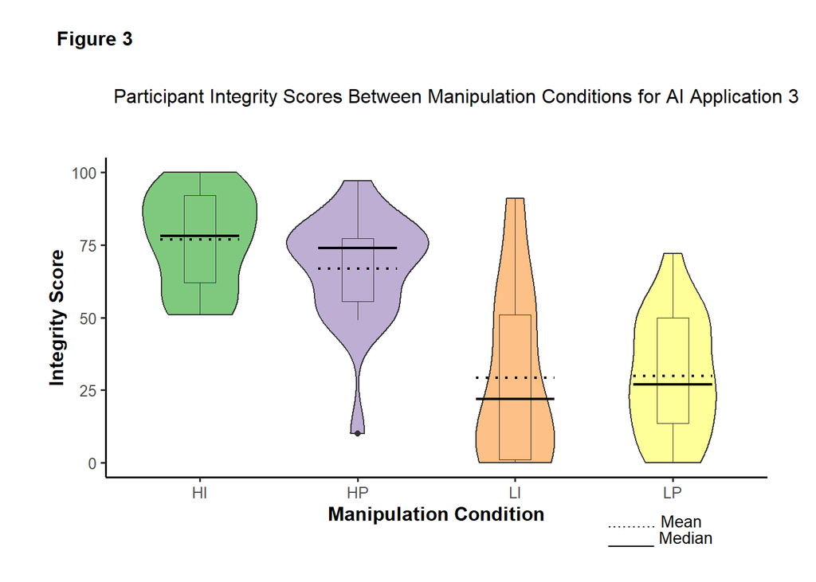

## Jitter-Plot Visualisation

### Risk

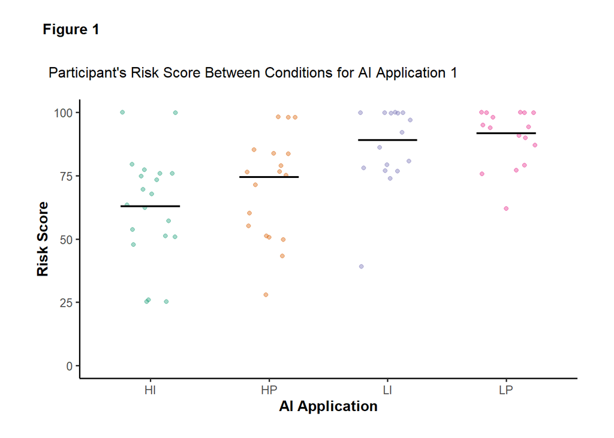

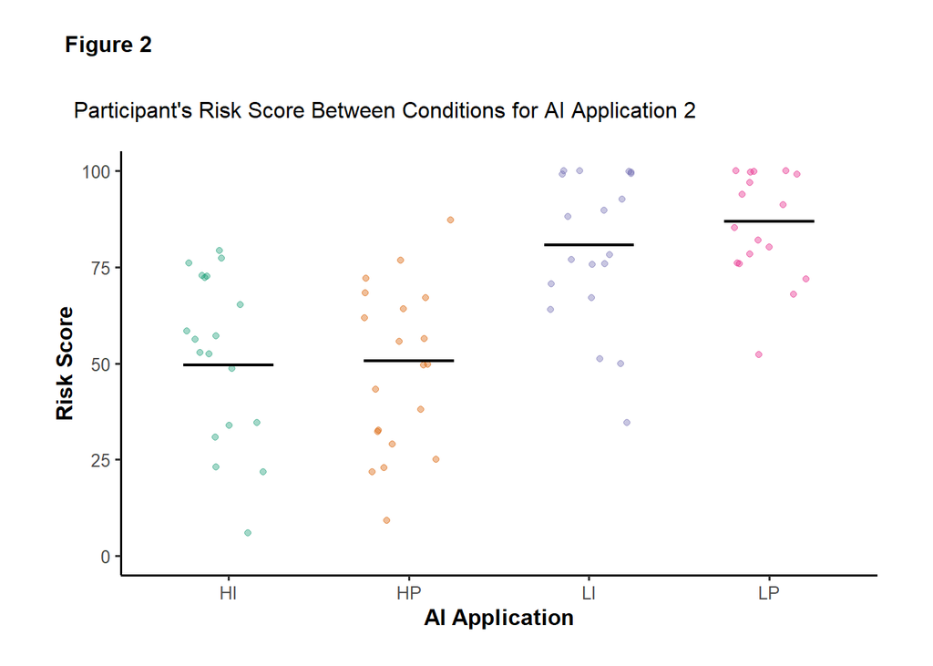

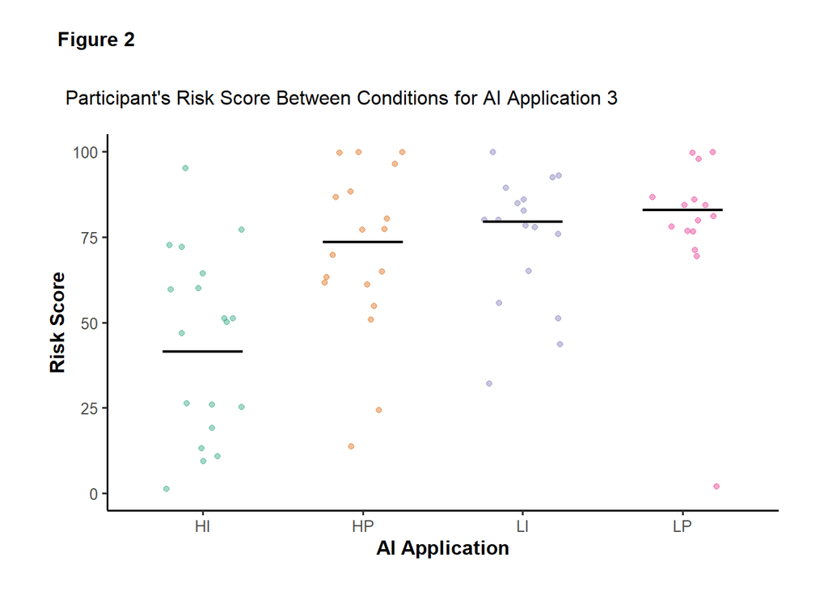

### Trust

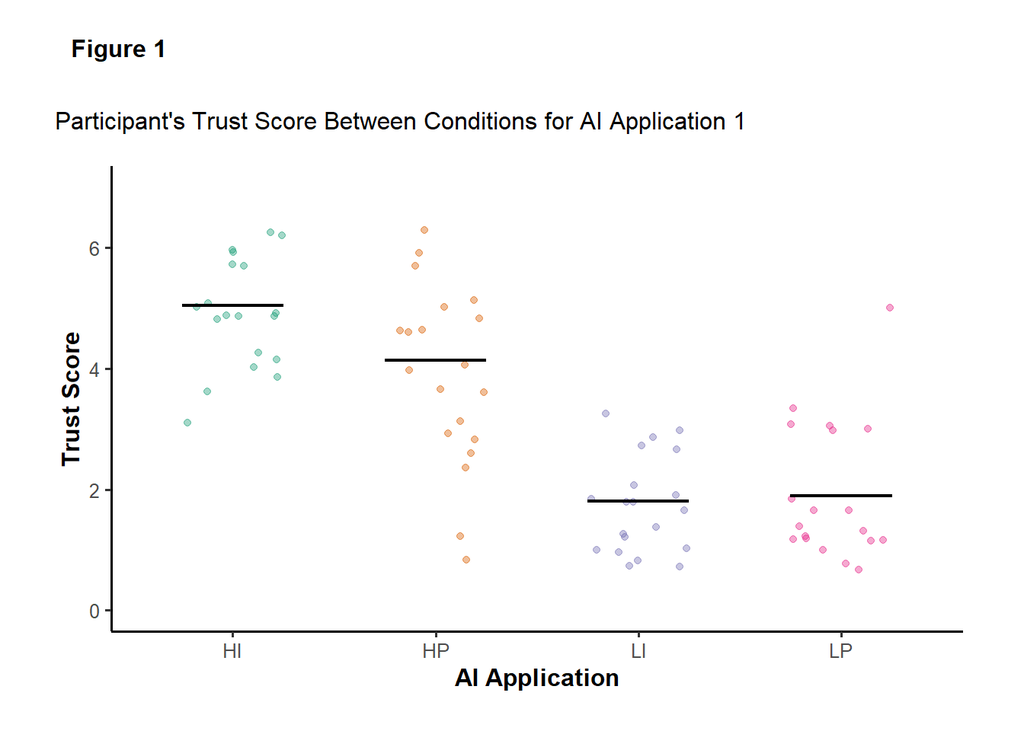

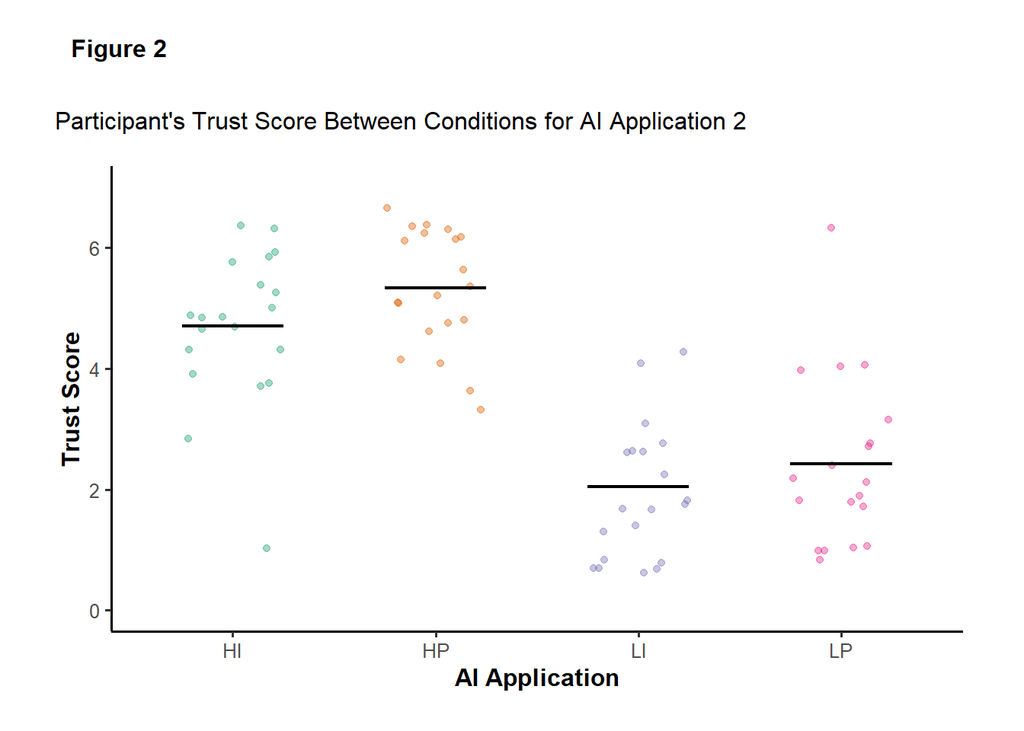

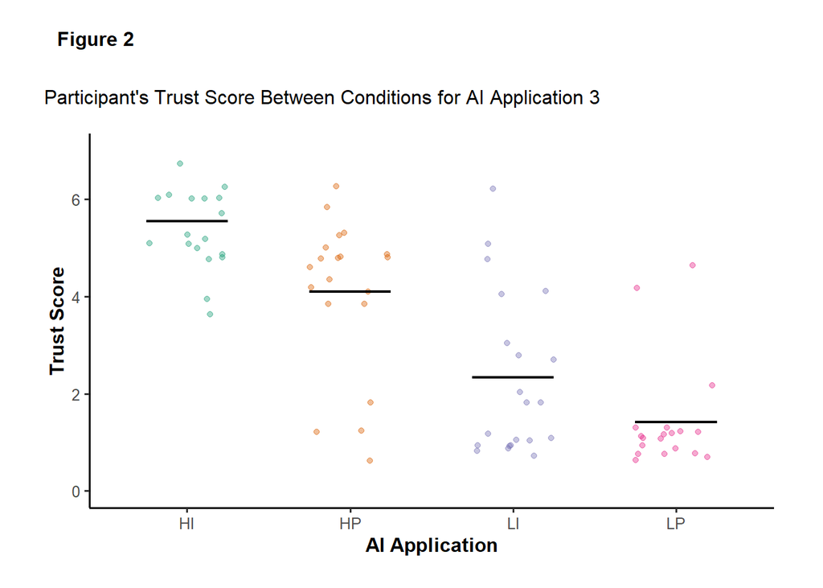

### Performance

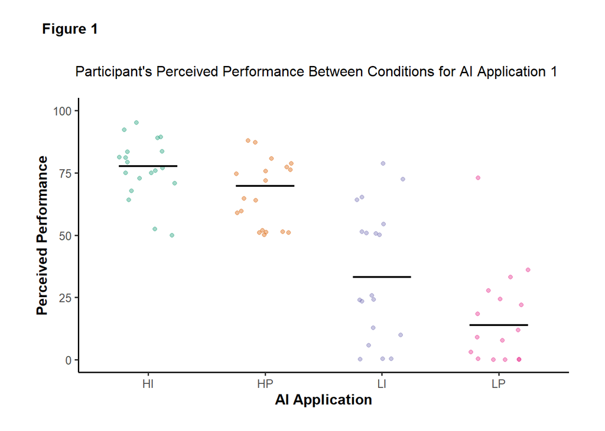

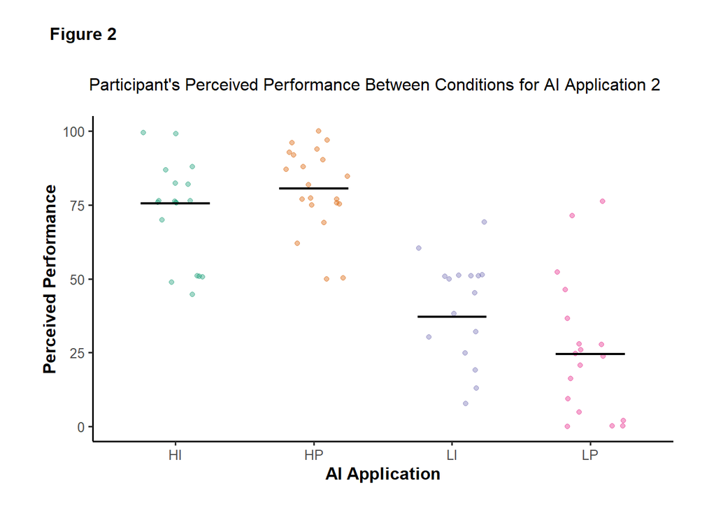

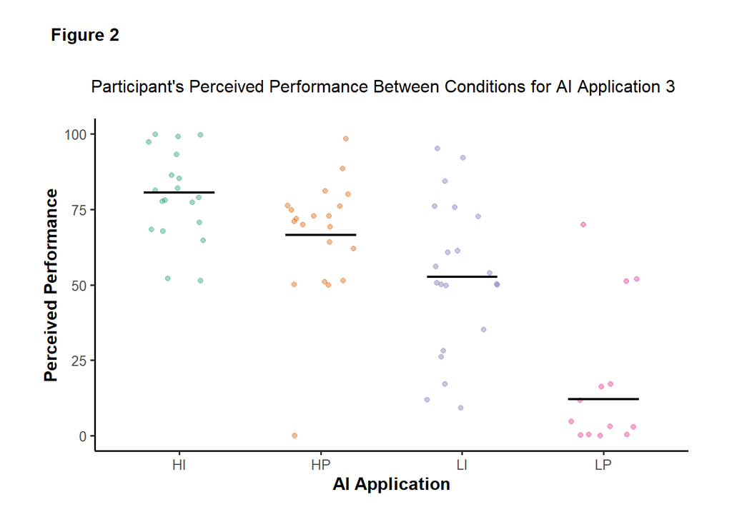

### Integrity

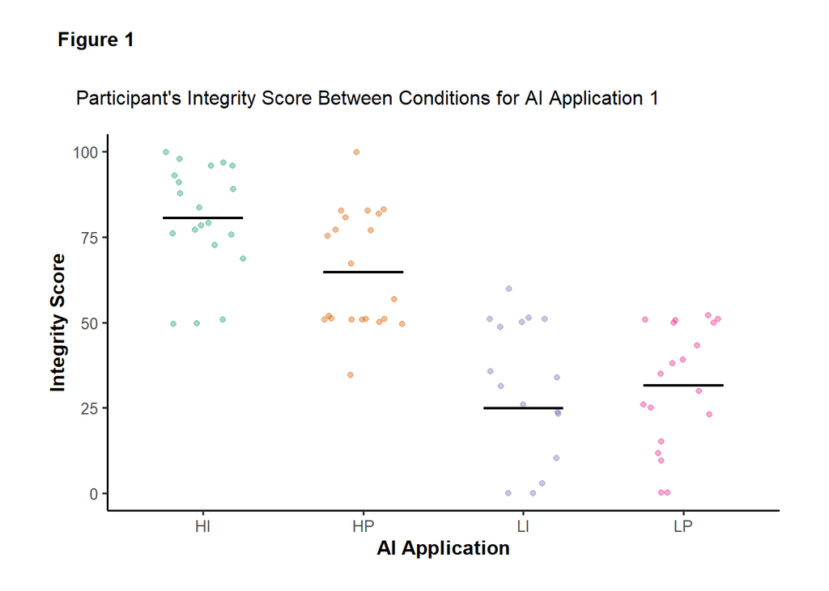

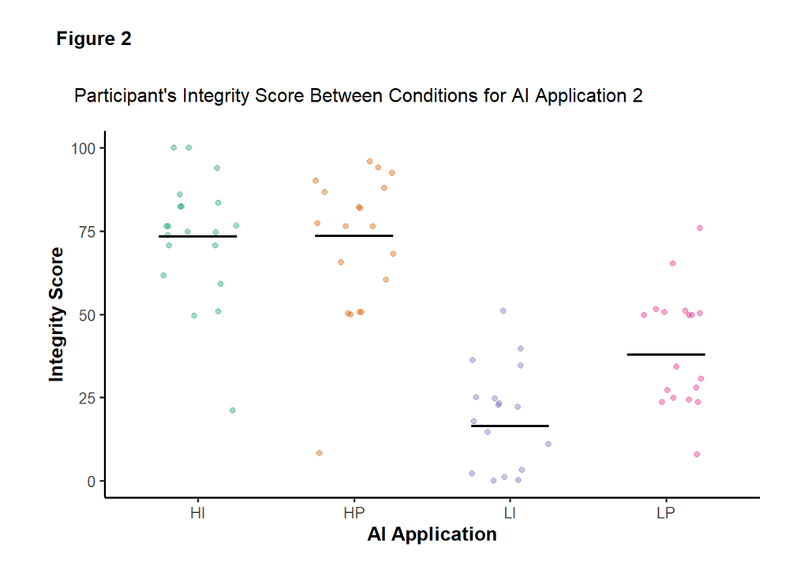

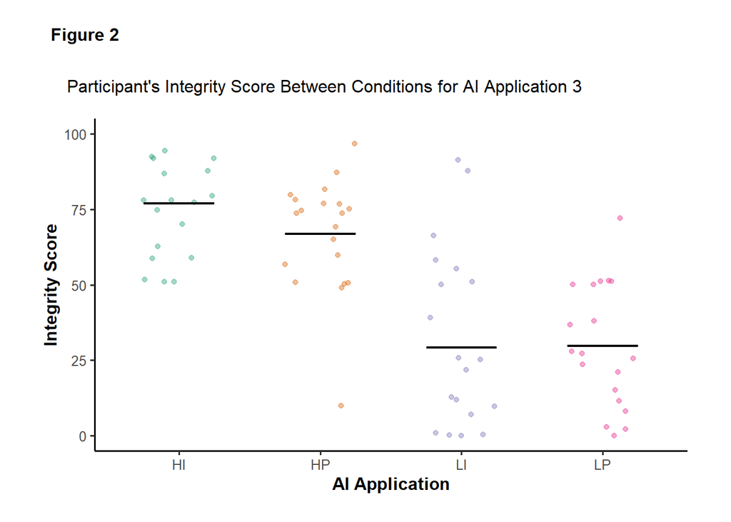

## Scatterplot Visualisation

### Risk/Performance Scores

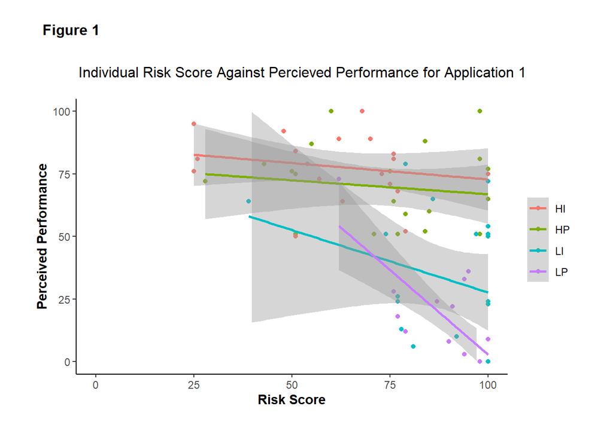

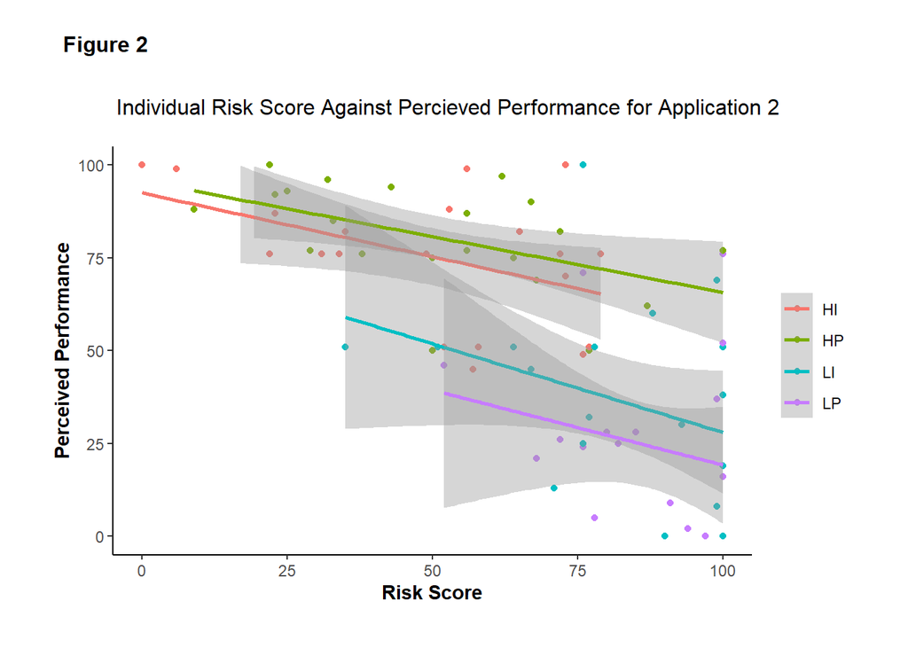

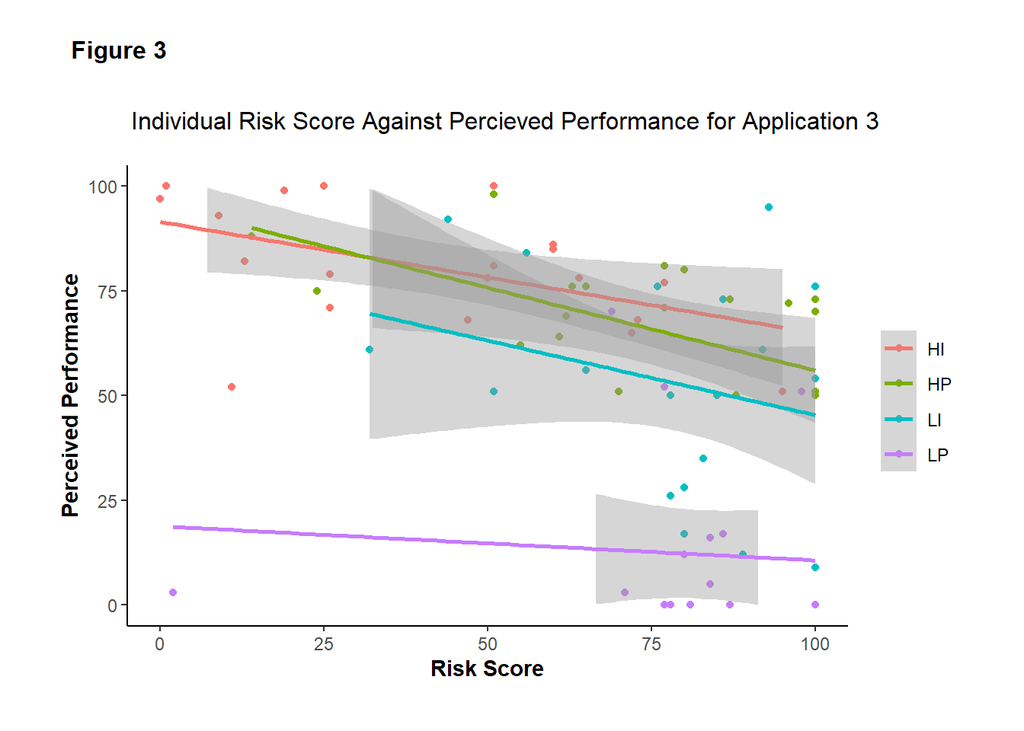

### Risk/Integrity Scores

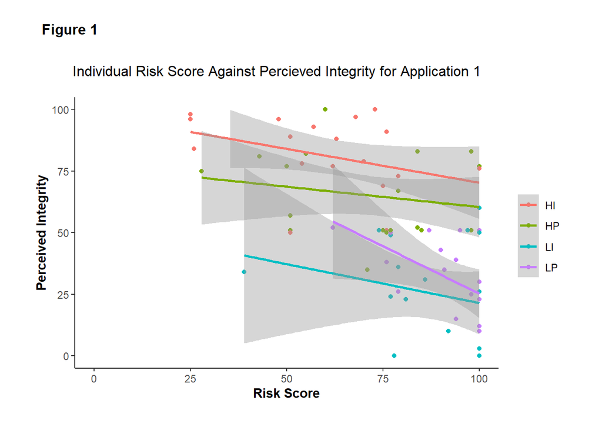

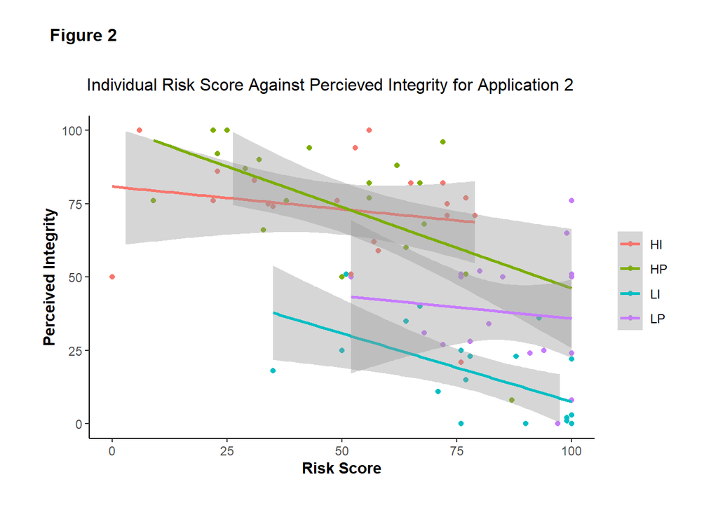

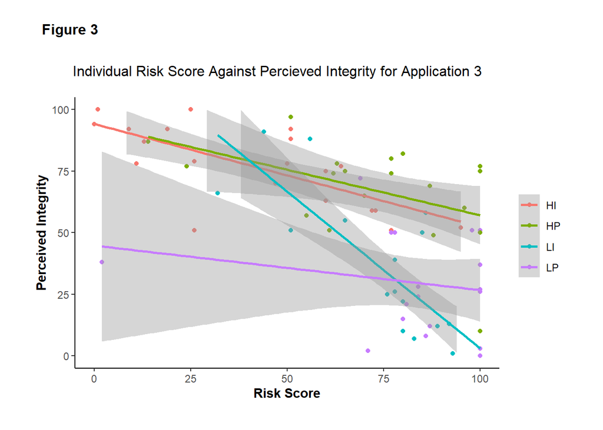

### Trust/Performance Scores

Trust Manipulation check for Performance Scores

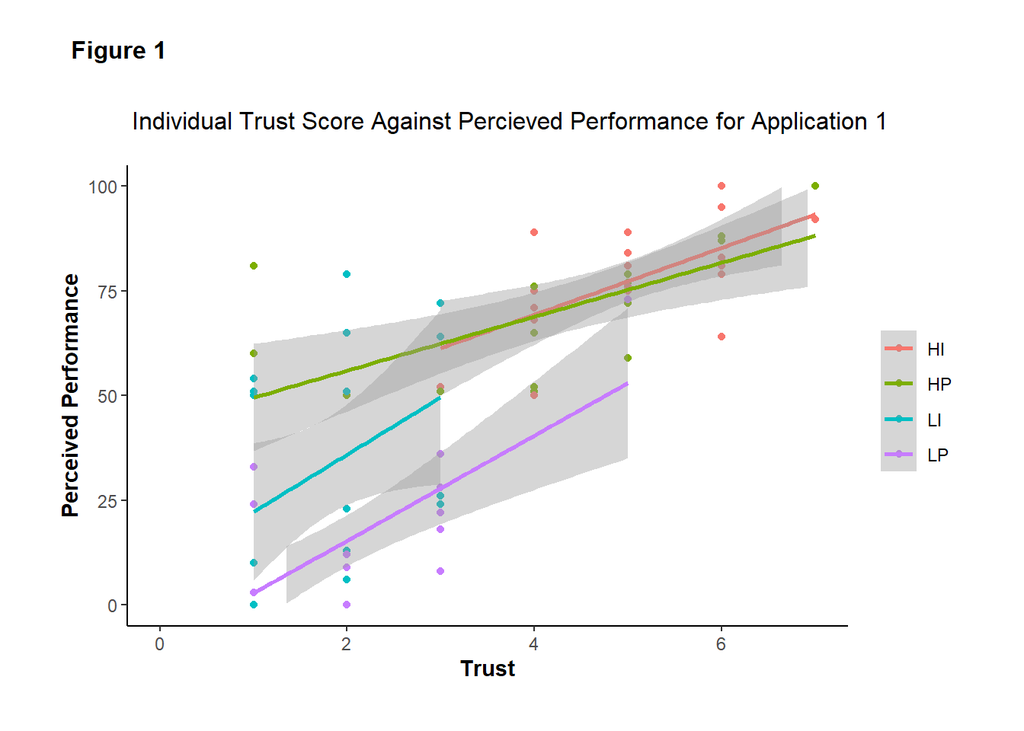

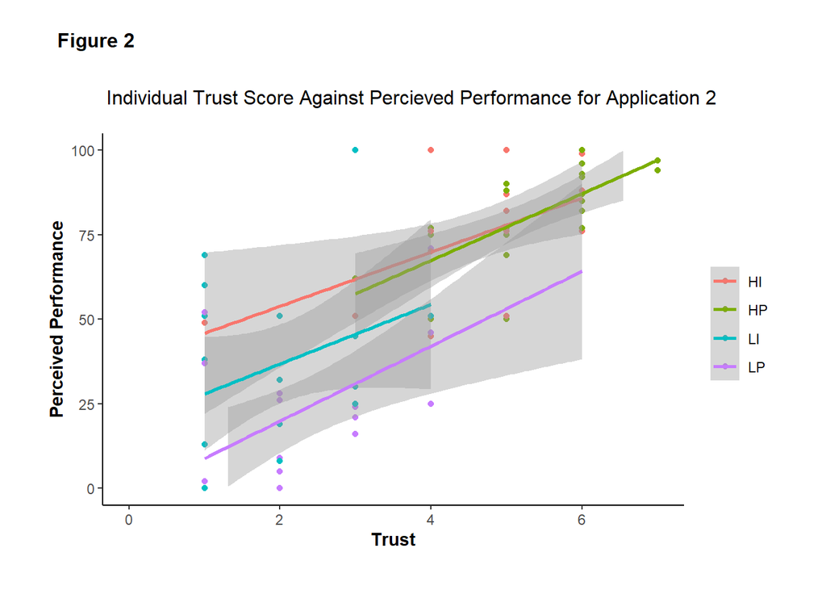

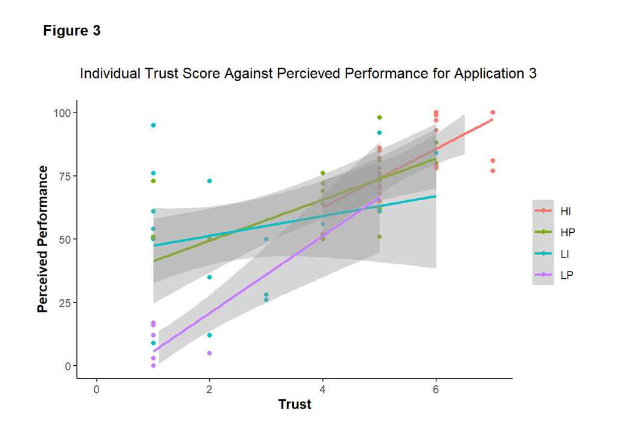

### Trust/Integrity Scores

Trust Manipulation check for Integrity Scores

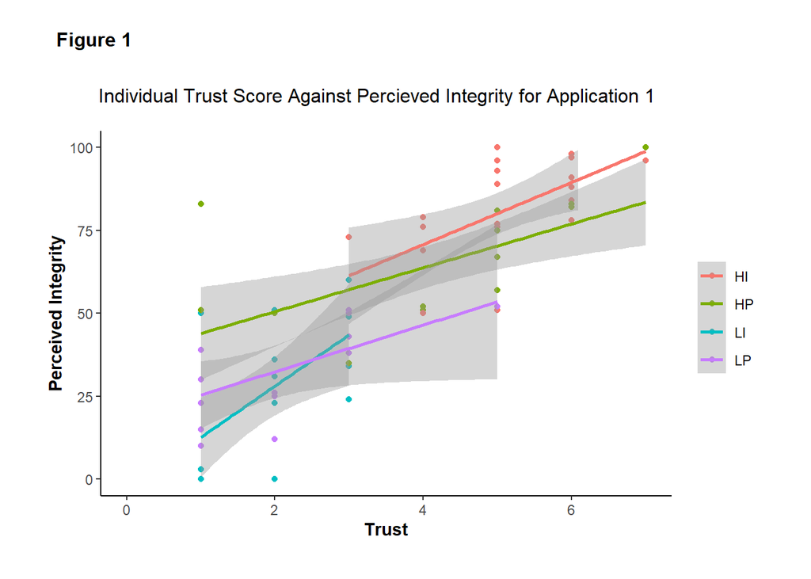

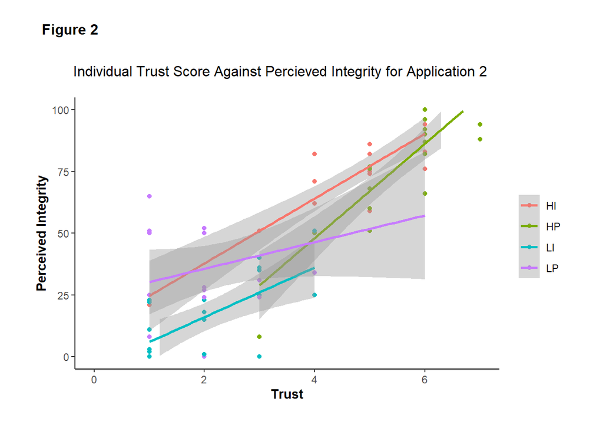

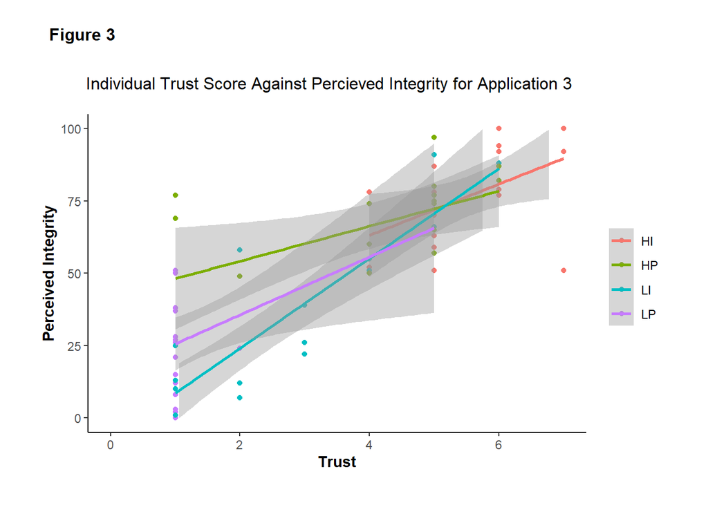

### Integrity/Performance Scores

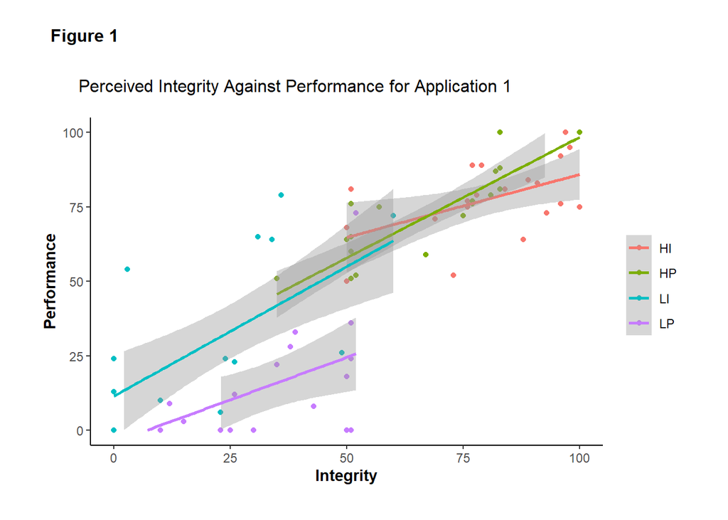

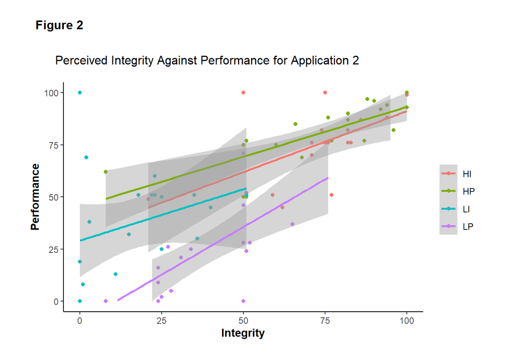

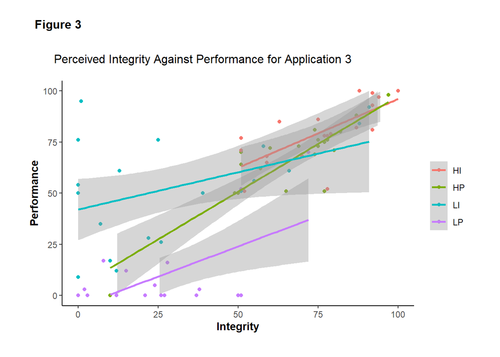

### Risk/Trust Scores

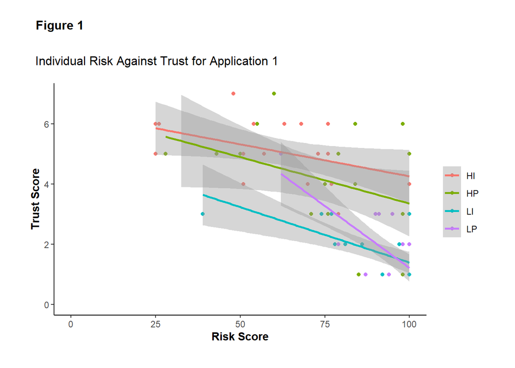

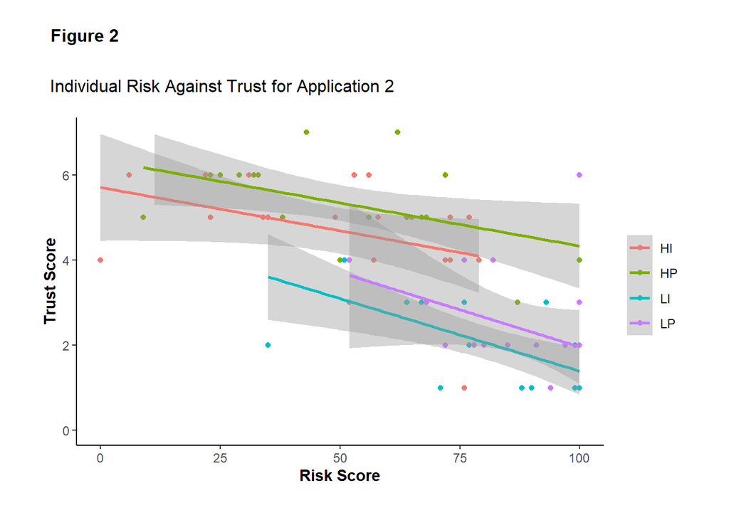

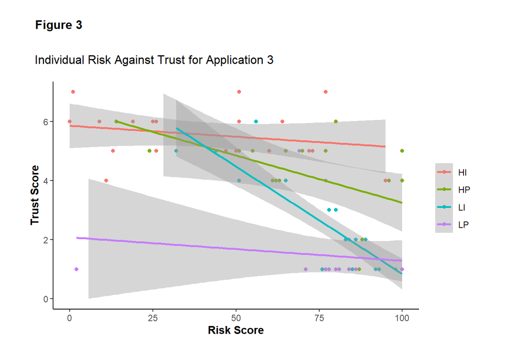

## Statistical Assumption Tests

### Equal Variance and Normality

```
##
##  Bartlett test of homogeneity of variances
##
## data:  Qualtrics_DF$Trust_S1 by Qualtrics_DF$S1_Condition
## Bartlett's K-squared = 9.4785, df = 3, p-value = 0.02356
```

```
##
##  Bartlett test of homogeneity of variances
##
## data:  Qualtrics_DF$Trust_S2 by Qualtrics_DF$S2_Condition
## Bartlett's K-squared = 1.9298, df = 3, p-value = 0.5871
```

```
##
##  Bartlett test of homogeneity of variances
##
## data:  Qualtrics_DF$Trust_S3 by Qualtrics_DF$S3_Condition
## Bartlett's K-squared = 8.71, df = 3, p-value = 0.03341
```

```
##
##  Bartlett test of homogeneity of variances
##
## data:  Qualtrics_DF$Performance_S1 by Qualtrics_DF$S1_Condition
## Bartlett's K-squared = 10.933, df = 3, p-value = 0.0121
```

```
##
##  Bartlett test of homogeneity of variances
##
## data:  Qualtrics_DF$Performance_S2 by Qualtrics_DF$S2_Condition
## Bartlett's K-squared = 7.8654, df = 3, p-value = 0.04888
```

```
##
##  Bartlett test of homogeneity of variances
##
## data:  Qualtrics_DF$Performance_S3 by Qualtrics_DF$S3_Condition
## Bartlett's K-squared = 4.6828, df = 3, p-value = 0.1966
```

```
##
##  Bartlett test of homogeneity of variances
##
## data:  Qualtrics_DF$Integrity_S1 by Qualtrics_DF$S1_Condition
## Bartlett's K-squared = 2.2193, df = 3, p-value = 0.5282
```

```
##
##  Bartlett test of homogeneity of variances
##
## data:  Qualtrics_DF$Integrity_S2 by Qualtrics_DF$S2_Condition
## Bartlett's K-squared = 2.4432, df = 3, p-value = 0.4856
```

```
##
##  Bartlett test of homogeneity of variances
##
## data:  Qualtrics_DF$Integrity_S3 by Qualtrics_DF$S3_Condition
## Bartlett's K-squared = 7.9788, df = 3, p-value = 0.04645
```

```
##
##  Shapiro-Wilk normality test
##
## data:  S1_HP$Performance_S1
## W = 0.91491, p-value = 0.06869
```

```
##
##  Shapiro-Wilk normality test
##
## data:  S2_HP$Performance_S2
## W = 0.92084, p-value = 0.09018
```

```
##
##  Shapiro-Wilk normality test
##
## data:  S3_HP$Performance_S3
## W = 0.83264, p-value = 0.002766
```

```
##
##  Shapiro-Wilk normality test
##
## data:  S1_LP$Performance_S1
## W = 0.76493, p-value = 0.0003693
```

```
##
##  Shapiro-Wilk normality test
##
## data:  S2_LP$Performance_S2
## W = 0.88844, p-value = 0.0302
```

```
##
##  Shapiro-Wilk normality test
##
## data:  S3_LP$Performance_S3
## W = 0.63224, p-value = 9.607e-06
```

```
##
##  Shapiro-Wilk normality test
##
## data:  S1_HI$Integrity_S1
## W = 0.88928, p-value = 0.02609
```

```
##
##  Shapiro-Wilk normality test
##
## data:  S2_HI$Integrity_S2
## W = 0.91241, p-value = 0.07086
```

```
##
##  Shapiro-Wilk normality test
##
## data:  S3_HI$Integrity_S3
## W = 0.92344, p-value = 0.1154
```

```
##
##  Shapiro-Wilk normality test
##
## data:  S1_LI$Integrity_S1
## W = 0.86263, p-value = 0.008743
```

```
##
##  Shapiro-Wilk normality test
##
## data:  S2_LI$Integrity_S2
## W = 0.8887, p-value = 0.02545
```

```
##
##  Shapiro-Wilk normality test
##
## data:  S3_LI$Integrity_S3
## W = 0.8709, p-value = 0.009946
```

```
##
##  Shapiro-Wilk normality test
##
## data:  S1_HP$Trust_S1
## W = 0.94517, p-value = 0.2752
```

```
##
##  Shapiro-Wilk normality test
##
## data:  S2_HP$Trust_S2
## W = 0.9094, p-value = 0.05343
```

```
##
##  Shapiro-Wilk normality test
##
## data:  S3_HP$Trust_S3
## W = 0.7888, p-value = 0.0005909
```

```
##
##  Shapiro-Wilk normality test
##
## data:  S1_LP$Trust_S1
## W = 0.76303, p-value = 0.0003481
```

```
##
##  Shapiro-Wilk normality test
##
## data:  S2_LP$Trust_S2
## W = 0.86313, p-value = 0.01105
```

```
##
##  Shapiro-Wilk normality test
##
## data:  S3_LP$Trust_S3
## W = 0.43835, p-value = 1.492e-07
```

```
##
##  Shapiro-Wilk normality test
##
## data:  S1_HI$Trust_S1
## W = 0.91798, p-value = 0.09059
```

```
##
##  Shapiro-Wilk normality test
##
## data:  S2_HI$Trust_S2
## W = 0.82807, p-value = 0.002337
```

```
##
##  Shapiro-Wilk normality test
##
## data:  S3_HI$Trust_S3
## W = 0.88446, p-value = 0.0213
```

```
##
##  Shapiro-Wilk normality test
##
## data:  S1_LI$Trust_S1
## W = 0.77774, p-value = 0.0004099
```

```
##
##  Shapiro-Wilk normality test
##
## data:  S2_LI$Trust_S2
## W = 0.83878, p-value = 0.003477
```

```
##
##  Shapiro-Wilk normality test
##
## data:  S3_LI$Trust_S3
## W = 0.80602, p-value = 0.000812
```

### Histograms

#### Frequency of Participant Risk Scores

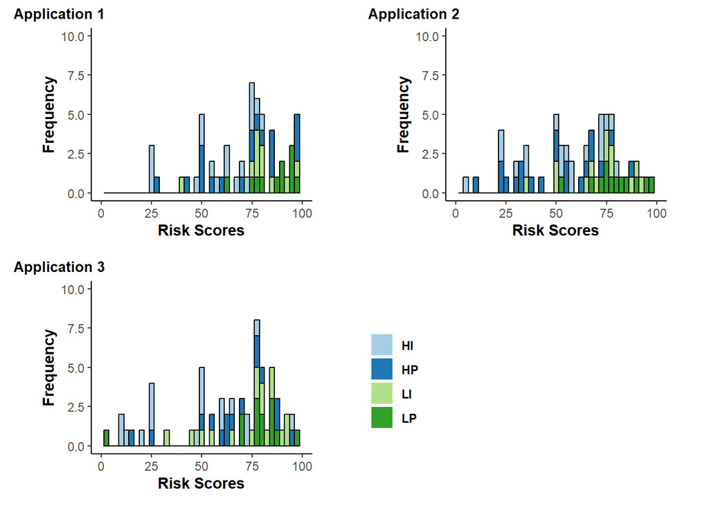

#### Frequency of Participant Trust Scores

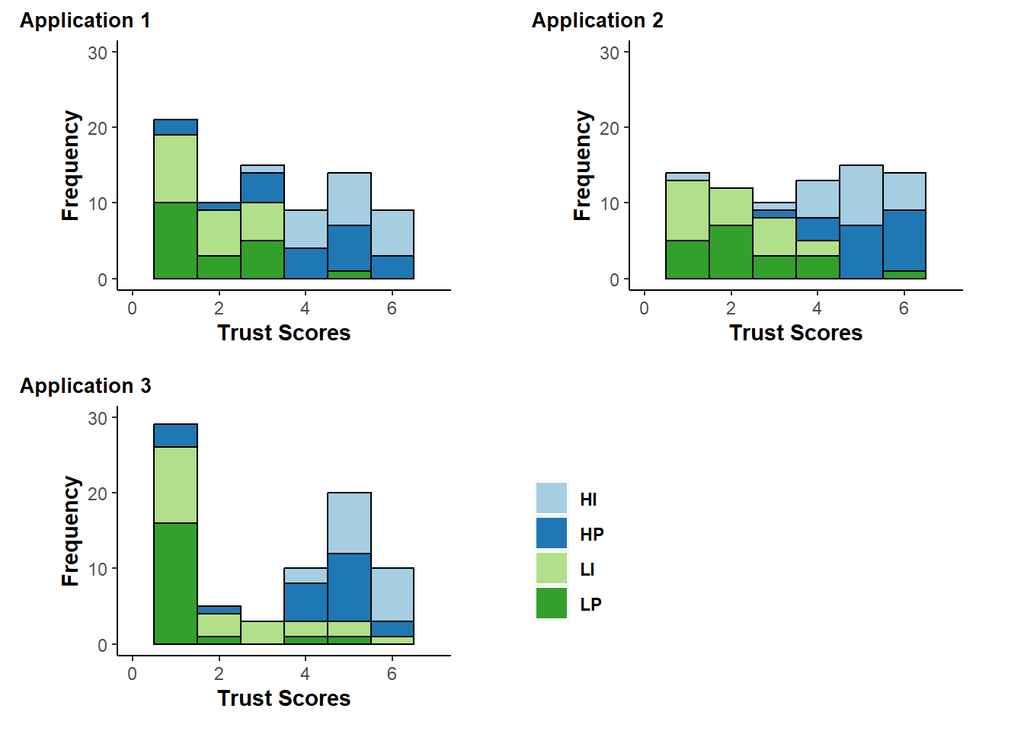

#### Frequency of Participant Performance Scores

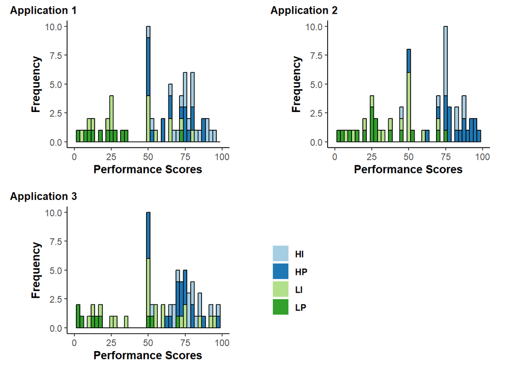

#### Frequency of Participant Integrity Scores

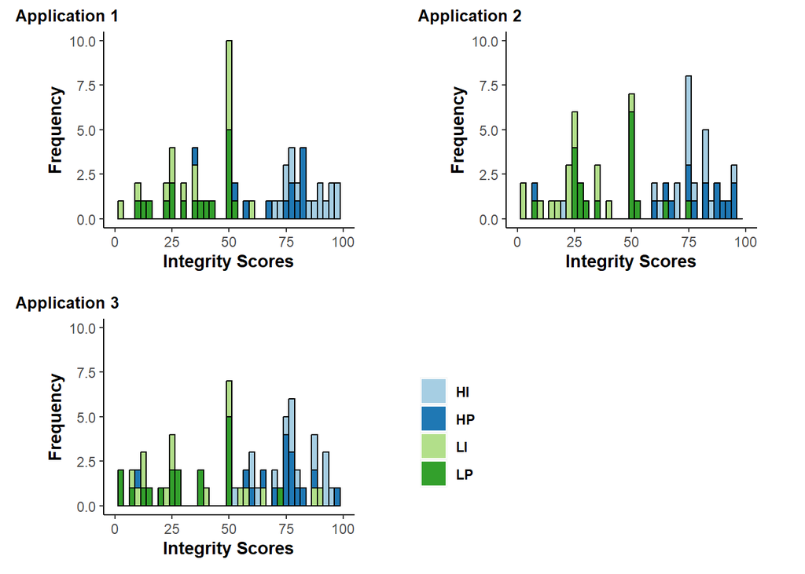

### QQ Plots

#### Risk QQ plots

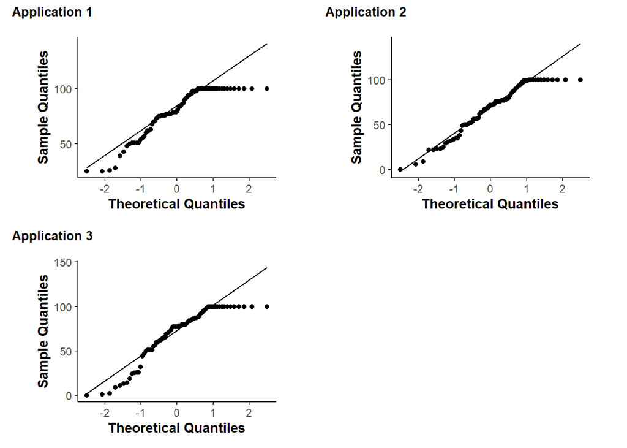

#### Trust QQ Plots

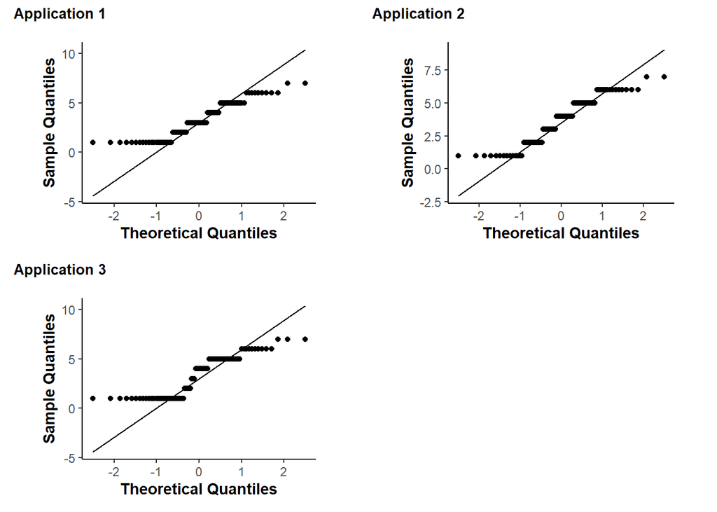

#### Perfromance QQ Plots

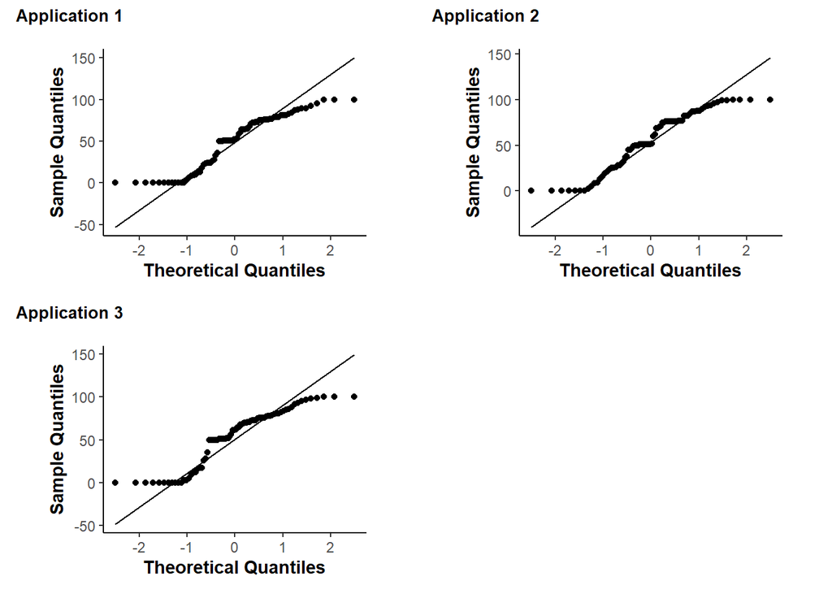

#### Integrity QQ Plots

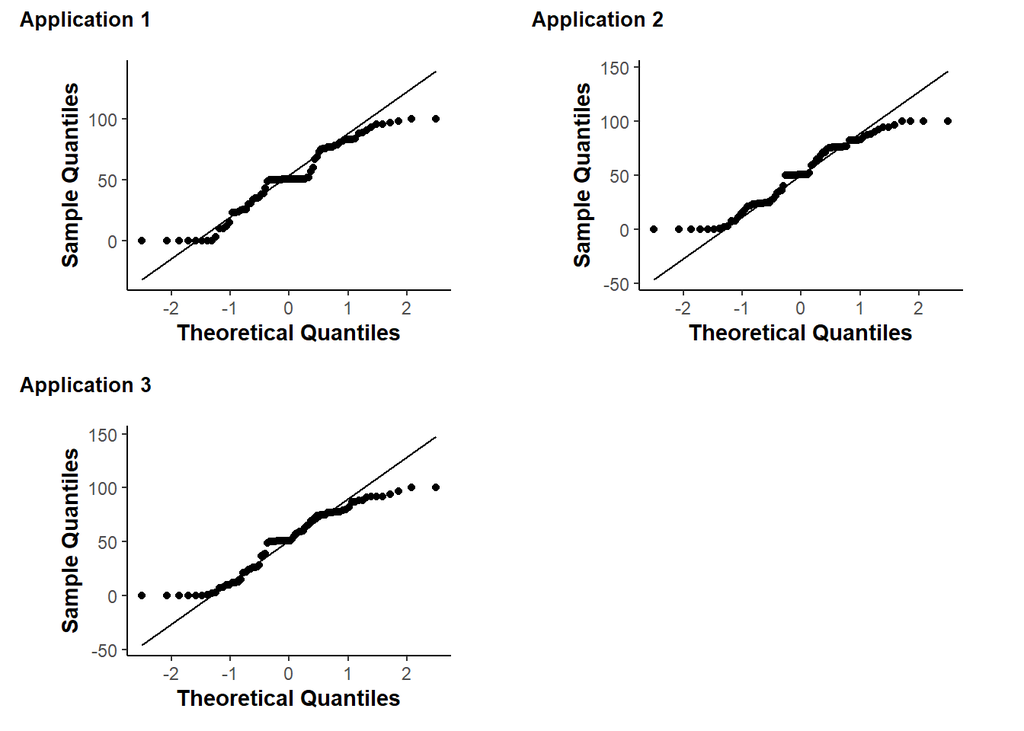

## One-Tailed T-Tests

### Performance Score Full Output

Car - HP/LP

```
##
##  Welch Two Sample t-test
##
## data:  Performance_S1 by S1_Condition
## t = 9.9685, df = 35.602, p-value = 3.819e-12
## alternative hypothesis: true difference in means between group HP and group LP is greater than 0
## 95 percent confidence interval:
##  46.31505      Inf
## sample estimates:
## mean in group HP mean in group LP
##          69.7619          14.0000
```

Cell Select - HP/LP

```
##
##  Welch Two Sample t-test
##
## data:  Performance_S2 by S2_Condition
## t = 9.0528, df = 29.099, p-value = 2.908e-10
## alternative hypothesis: true difference in means between group HP and group LP is greater than 0
## 95 percent confidence interval:
##  45.52715      Inf
## sample estimates:
## mean in group HP mean in group LP
##         80.57143         24.52632
```

DataDoc - HP/LP

```
##
##  Welch Two Sample t-test
##
## data:  Performance_S3 by S3_Condition
## t = 8.1856, df = 36.574, p-value = 4.339e-10
## alternative hypothesis: true difference in means between group HP and group LP is greater than 0
## 95 percent confidence interval:
##  43.22219      Inf
## sample estimates:
## mean in group HP mean in group LP
##         66.50000         12.05263
```

### Performance Score Summary

**Autonomous Vehicle S1**

.y.

group1

group2

n1

n2

statistic

df

p

p.adj

p.adj.signif

Performance_S1

HI

HP

20

21

1.745468

37.84344

4.40e-02

4.40e-02

Performance_S1

HI

LI

20

20

6.702001

27.30810

1.61e-07

1.61e-07

Performance_S1

HI

LP

20

19

12.226028

31.49760

8.48e-14

8.48e-14

Performance_S1

HP

LI

21

20

5.266343

30.89706

5.05e-06

5.05e-06

Performance_S1

HP

LP

21

19

9.968452

35.60169

3.82e-12

3.82e-12

Performance_S1

LI

LP

20

19

2.587025

34.23742

7.00e-03

7.00e-03

**Virtual Assistant Cell Select S2**

| .y. | group1 | group2 | n1 | n2 | statistic | df | p | p.adj | p.adj.signif |
| --- | --- | --- | --- | --- | --- | --- | --- | --- | --- |
| Performance_S2 | HI | HP | 20 | 21 | -0.9993234 | 36.14357 | 8.38e-01 | 8.38e-01 | ns |
| Performance_S2 | HI | LI | 20 | 20 | 5.4244091 | 33.82207 | 2.45e-06 | 2.45e-06 | **** |
| Performance_S2 | HI | LP | 20 | 19 | 7.6067599 | 33.81056 | 4.01e-09 | 4.01e-09 | **** |
| Performance_S2 | HP | LI | 21 | 20 | 6.5929709 | 29.11446 | 1.56e-07 | 1.56e-07 | **** |
| Performance_S2 | HP | LP | 21 | 19 | 9.0527992 | 29.09938 | 2.91e-10 | 2.91e-10 | **** |
| Performance_S2 | LI | LP | 20 | 19 | 1.6040535 | 36.89923 | 5.90e-02 | 5.90e-02 | ns |

**DataDoc S3**

.y.

group1

group2

n1

n2

statistic

df

p

p.adj

p.adj.signif

Performance_S3

HI

HP

20

20

2.486763

35.17992

9.00e-03

9.00e-03

Performance_S3

HI

LI

20

21

4.344051

33.12747

6.24e-05

6.24e-05

Performance_S3

HI

LP

20

19

11.525392

32.26771

2.81e-13

2.81e-13

Performance_S3

HP

LI

20

21

1.955815

38.00900

2.90e-02

2.90e-02

Performance_S3

HP

LP

20

19

8.185639

36.57443

4.34e-10

4.34e-10

Performance_S3

LI

LP

21

19

5.547389

37.88401

1.20e-06

1.20e-06

### Intergrity Score Full Output

Car - HI/LI

```
##
##  Welch Two Sample t-test
##
## data:  Integrity_S1 by S1_Condition
## t = 9.1654, df = 34.675, p-value = 4.3e-11
## alternative hypothesis: true difference in means between group HI and group LI is greater than 0
## 95 percent confidence interval:
##  45.34797      Inf
## sample estimates:
## mean in group HI mean in group LI
##            80.55            24.95
```

Cell Select - HI/LI

```
##
##  Welch Two Sample t-test
##
## data:  Integrity_S2 by S2_Condition
## t = 10.469, df = 37.178, p-value = 6.122e-13
## alternative hypothesis: true difference in means between group HI and group LI is greater than 0
## 95 percent confidence interval:
##  47.60555      Inf
## sample estimates:
## mean in group HI mean in group LI
##            73.25            16.50
```

Airline - HI/LI

```
##
##  Welch Two Sample t-test
##
## data:  Integrity_S3 by S3_Condition
## t = 6.3856, df = 31.46, p-value = 1.927e-07
## alternative hypothesis: true difference in means between group HI and group LI is greater than 0
## 95 percent confidence interval:
##  34.97554      Inf
## sample estimates:
## mean in group HI mean in group LI
##          76.8500          29.2381
```

### Integrity Score Summary

**Autonomous Vehicle S1**

| .y. | group1 | group2 | n1 | n2 | statistic | df | p | p.adj | p.adj.signif |
| --- | --- | --- | --- | --- | --- | --- | --- | --- | --- |
| Integrity_S1 | HI | HP | 20 | 21 | 3.072269 | 38.97781 | 2.00e-03 | 2.00e-03 | ** |
| Integrity_S1 | HI | LI | 20 | 20 | 9.165421 | 34.67539 | 4.30e-11 | 4.30e-11 | **** |
| Integrity_S1 | HI | LP | 20 | 19 | 9.011223 | 36.01916 | 4.62e-11 | 4.62e-11 | **** |
| Integrity_S1 | HP | LI | 21 | 20 | 6.432523 | 35.97585 | 9.24e-08 | 9.24e-08 | **** |
| Integrity_S1 | HP | LP | 21 | 19 | 5.953214 | 37.25023 | 3.54e-07 | 3.54e-07 | **** |
| Integrity_S1 | LI | LP | 20 | 19 | -1.045215 | 36.16015 | 8.49e-01 | 8.49e-01 | ns |

**Virtual Assistant Cell Select S2**

| .y. | group1 | group2 | n1 | n2 | statistic | df | p | p.adj | p.adj.signif |
| --- | --- | --- | --- | --- | --- | --- | --- | --- | --- |
| Integrity_S2 | HI | HP | 20 | 21 | -0.0426973 | 38.10151 | 5.17e-01 | 5.17e-01 | ns |
| Integrity_S2 | HI | LI | 20 | 20 | 10.4687365 | 37.17769 | 6.12e-13 | 6.12e-13 | **** |
| Integrity_S2 | HI | LP | 20 | 19 | 5.8616402 | 36.63952 | 5.00e-07 | 5.00e-07 | **** |
| Integrity_S2 | HP | LI | 21 | 20 | 9.4060156 | 35.90064 | 1.60e-11 | 1.60e-11 | **** |
| Integrity_S2 | HP | LP | 21 | 19 | 5.3867256 | 37.88174 | 1.99e-06 | 1.99e-06 | **** |
| Integrity_S2 | LI | LP | 20 | 19 | -3.7814881 | 34.89478 | 1.00e+00 | 1.00e+00 | ns |

**Airline Profiling S3**

.y.

group1

group2

n1

n2

statistic

df

p

p.adj

p.adj.signif

Integrity_S3

HI

HP

20

20

1.77846172

37.28319

4.20e-02

4.20e-02

Integrity_S3

HI

LI

20

21

6.38558527

31.45993

1.93e-07

1.93e-07

Integrity_S3

HI

LP

20

19

7.87887226

34.46110

1.62e-09

1.62e-09

Integrity_S3

HP

LI

20

21

4.86479283

34.08316

1.28e-05

1.28e-05

Integrity_S3

HP

LP

20

19

5.86645067

36.32393

5.08e-07

5.08e-07

Integrity_S3

LI

LP

21

19

-0.06875588

35.63817

5.27e-01

5.27e-01

ns

## Two Tailed T-Tests

### Trust Score Full Output

Car - HP/LP

```
##
##  Welch Two Sample t-test
##
## data:  Trust_S1 by S1_Condition
## t = 5.0945, df = 36.039, p-value = 1.122e-05
## alternative hypothesis: true difference in means between group HP and group LP is not equal to 0
## 95 percent confidence interval:
##  1.353192 3.143048
## sample estimates:
## mean in group HP mean in group LP
##         4.142857         1.894737
```

Car - HI/LI

```
##
##  Welch Two Sample t-test
##
## data:  Trust_S1 by S1_Condition
## t = 11.173, df = 36.822, p-value = 2.185e-13
## alternative hypothesis: true difference in means between group HI and group LI is not equal to 0
## 95 percent confidence interval:
##  2.660546 3.839454
## sample estimates:
## mean in group HI mean in group LI
##             5.05             1.80
```

Cell Select - HP/LP

```
##
##  Welch Two Sample t-test
##
## data:  Trust_S2 by S2_Condition
## t = 7.6581, df = 33.366, p-value = 7.561e-09
## alternative hypothesis: true difference in means between group HP and group LP is not equal to 0
## 95 percent confidence interval:
##  2.138898 3.685664
## sample estimates:
## mean in group HP mean in group LP
##         5.333333         2.421053
```

Cell Select - HI/LI

```
##
##  Welch Two Sample t-test
##
## data:  Trust_S2 by S2_Condition
## t = 7.3684, df = 37.191, p-value = 8.925e-09
## alternative hypothesis: true difference in means between group HI and group LI is not equal to 0
## 95 percent confidence interval:
##  1.921423 3.378577
## sample estimates:
## mean in group HI mean in group LI
##             4.70             2.05
```

DataDoc - HP/LP

```
##
##  Welch Two Sample t-test
##
## data:  Trust_S3 by S3_Condition
## t = 6.1144, df = 34.245, p-value = 5.949e-07
## alternative hypothesis: true difference in means between group HP and group LP is not equal to 0
## 95 percent confidence interval:
##  1.788781 3.569113
## sample estimates:
## mean in group HP mean in group LP
##         4.100000         1.421053
```

Airline - HI/LI

```
##
##  Welch Two Sample t-test
##
## data:  Trust_S3 by S3_Condition
## t = 7.9252, df = 31.278, p-value = 5.655e-09
## alternative hypothesis: true difference in means between group HI and group LI is not equal to 0
## 95 percent confidence interval:
##  2.389166 4.044168
## sample estimates:
## mean in group HI mean in group LI
##         5.550000         2.333333
```

### Trust Scores Summary

**Autonomous Vehicle S1**

.y.

group1

group2

n1

n2

statistic

df

p

p.adj

p.adj.signif

Trust_S1

HI

HP

20

21

2.1682478

33.51160

3.70e-02

3.70e-02

Trust_S1

HI

LI

20

20

11.1733826

36.82217

2.19e-13

2.19e-13

Trust_S1

HI

LP

20

19

9.1302357

35.68482

7.24e-11

7.24e-11

Trust_S1

HP

LI

21

20

5.8588475

30.19326

2.02e-06

2.02e-06

Trust_S1

HP

LP

21

19

5.0945191

36.03898

1.12e-05

1.12e-05

Trust_S1

LI

LP

20

19

-0.2933483

32.73316

7.71e-01

7.71e-01

ns

**Virtual Assistant Cell Select S2**

| .y. | group1 | group2 | n1 | n2 | statistic | df | p | p.adj | p.adj.signif |
| --- | --- | --- | --- | --- | --- | --- | --- | --- | --- |
| Trust_S2 | HI | HP | 20 | 21 | -1.8027897 | 37.06774 | 8.00e-02 | 8.00e-02 | ns |
| Trust_S2 | HI | LI | 20 | 20 | 7.3684461 | 37.19078 | 8.93e-09 | 8.93e-09 | **** |
| Trust_S2 | HI | LP | 20 | 19 | 5.5333737 | 36.16354 | 2.88e-06 | 2.88e-06 | **** |
| Trust_S2 | HP | LI | 21 | 20 | 10.1646838 | 38.73662 | 1.74e-12 | 1.74e-12 | **** |
| Trust_S2 | HP | LP | 21 | 19 | 7.6580566 | 33.36629 | 7.56e-09 | 7.56e-09 | **** |
| Trust_S2 | LI | LP | 20 | 19 | -0.9563163 | 34.04320 | 3.46e-01 | 3.46e-01 | ns |

**DataDoc (HP LP) Airline Profiling (HI LI)**

.y.

group1

group2

n1

n2

statistic

df

p

p.adj

p.adj.signif

Trust_S3

HI

HP

20

20

3.568231

29.82595

1.00e-03

1.00e-03

Trust_S3

HI

LI

20

21

7.925158

31.27751

5.66e-09

5.66e-09

Trust_S3

HI

LP

20

19

12.710995

34.28469

1.57e-14

1.57e-14

Trust_S3

HP

LI

20

21

3.524980

38.97114

1.00e-03

1.00e-03

Trust_S3

HP

LP

20

19

6.114411

34.24509

5.95e-07

5.95e-07

Trust_S3

LI

LP

21

19

2.084316

35.64794

4.40e-02

4.40e-02

## Exploratory Analysis

**Exploratory Analysis**

### Regression Models

```
##
## Call:
## lm(formula = Trust_S1 ~ Performance_S1, data = Qualtrics_DF)
##
## Residuals:
##     Min      1Q  Median      3Q     Max
## -3.6937 -0.3367  0.0186  0.6721  2.0817
##
## Coefficients:
##                Estimate Std. Error t value Pr(>|t|)
## (Intercept)    0.998917   0.227404   4.393 3.48e-05 ***
## Performance_S1 0.045615   0.003864  11.806  < 2e-16 ***
## ---
## Signif. codes:  0 '***' 0.001 '**' 0.01 '*' 0.05 '.' 0.1 ' ' 1
##
## Residual standard error: 1.108 on 78 degrees of freedom
## Multiple R-squared:  0.6412, Adjusted R-squared:  0.6366
## F-statistic: 139.4 on 1 and 78 DF,  p-value: < 2.2e-16
```

```
##                         b      beta
## Performance_S1 0.04561465 0.8007295
```

```
##
## Call:
## lm(formula = Trust_S1 ~ Performance_S1 + Integrity_S1, data = Qualtrics_DF)
##
## Residuals:
##     Min      1Q  Median      3Q     Max
## -3.9459 -0.3021  0.2391  0.6532  1.4087
##
## Coefficients:
##                Estimate Std. Error t value Pr(>|t|)
## (Intercept)    0.582632   0.224857   2.591 0.011439 *
## Performance_S1 0.022515   0.006262   3.595 0.000569 ***
## Integrity_S1   0.030597   0.006904   4.432 3.05e-05 ***
## ---
## Signif. codes:  0 '***' 0.001 '**' 0.01 '*' 0.05 '.' 0.1 ' ' 1
##
## Residual standard error: 0.9957 on 77 degrees of freedom
## Multiple R-squared:  0.7141, Adjusted R-squared:  0.7067
## F-statistic: 96.16 on 2 and 77 DF,  p-value: < 2.2e-16
```

```
##                         b      beta
## Performance_S1 0.02251532 0.3952389
## Integrity_S1   0.03059695 0.4871873
```

```
##
## Call:
## lm(formula = Trust_S1 ~ Performance_S1 + Integrity_S1 + Risk_S1,
##     data = Qualtrics_DF)
##
## Residuals:
##     Min      1Q  Median      3Q     Max
## -3.1492 -0.5103  0.1081  0.6470  1.5115
##
## Coefficients:
##                 Estimate Std. Error t value Pr(>|t|)
## (Intercept)     3.062789   0.631241   4.852 6.36e-06 ***
## Performance_S1  0.017861   0.005800   3.080 0.002885 **
## Integrity_S1    0.024739   0.006430   3.847 0.000247 ***
## Risk_S1        -0.024630   0.005931  -4.153 8.51e-05 ***
## ---
## Signif. codes:  0 '***' 0.001 '**' 0.01 '*' 0.05 '.' 0.1 ' ' 1
##
## Residual standard error: 0.9048 on 76 degrees of freedom
## Multiple R-squared:  0.767,  Adjusted R-squared:  0.7578
## F-statistic: 83.38 on 3 and 76 DF,  p-value: < 2.2e-16
```

```
##                          b       beta
## Performance_S1  0.01786147  0.3135442
## Integrity_S1    0.02473923  0.3939163
## Risk_S1        -0.02463010 -0.2844836
```

### Regression Comparison

Regression Model Comparison

|  | Trust_S1 | Trust_S1 | Trust_S1 | Trust_S1 |
| --- | --- | --- | --- | --- |
| Predictors | p | p | p | p |
| (Intercept) | **<0.001** | **<0.001** | **0.011** | **<0.001** |
| Performance S1 |  | **<0.001** | **0.001** | **0.003** |
| Integrity S1 |  |  | **<0.001** | **<0.001** |
| Risk S1 |  |  |  | **<0.001** |
| Observations | 80 | 80 | 80 | 80 |
| R<sup>2</sup> / R<sup>2</sup> adjusted | 0.000 / 0.000 | 0.641 / 0.637 | 0.714 / 0.707 | 0.767 / 0.758 |
| AIC | 327.448 | 247.456 | 231.280 | 216.921 |

ANOVA between models *Significance interpreted as improvement in model due to addition of variable*

| Res.Df | RSS | Df | Sum.of.Sq | F | Pr..F. |
| --- | --- | --- | --- | --- | --- |
| 79 | 267.00 | NA | NA | NA | NA |
| 78 | 95.81 | 1 | 171.19 | 209.11 | 0.00 |
| 77 | 76.34 | 1 | 19.47 | 23.78 | 0.00 |
| 76 | 62.22 | 1 | 14.12 | 17.24 | 0.00 |

### Correlations - Collapsed conditions

```
##
##  Pearson's product-moment correlation
##
## data:  Qualtrics_DF$Performance_S1 and Qualtrics_DF$Integrity_S1
## t = 13.261, df = 78, p-value < 2.2e-16
## alternative hypothesis: true correlation is not equal to 0
## 95 percent confidence interval:
##  0.7496904 0.8893828
## sample estimates:
##       cor
## 0.8323096
```

```
##
##  Pearson's product-moment correlation
##
## data:  Qualtrics_DF$Performance_S2 and Qualtrics_DF$Integrity_S2
## t = 10.099, df = 78, p-value = 8.135e-16
## alternative hypothesis: true correlation is not equal to 0
## 95 percent confidence interval:
##  0.6386821 0.8344648
## sample estimates:
##       cor
## 0.7527642
```

```
##
##  Pearson's product-moment correlation
##
## data:  Qualtrics_DF$Performance_S3 and Qualtrics_DF$Integrity_S3
## t = 8.9337, df = 78, p-value = 1.451e-13
## alternative hypothesis: true correlation is not equal to 0
## 95 percent confidence interval:
##  0.5824414 0.8050734
## sample estimates:
##       cor
## 0.7111507
```

### Correlations - Between Condition Type (P or I) for each AI Application

**Performance Conditions - Correlations between performance and integrity scores for each Application**

```
##
##  Pearson's product-moment correlation
##
## data:  S1_Performance_Conditions$Performance_S1 and S1_Performance_Conditions$Integrity_S1
## t = 10.048, df = 38, p-value = 2.989e-12
## alternative hypothesis: true correlation is not equal to 0
## 95 percent confidence interval:
##  0.7363946 0.9196863
## sample estimates:
##       cor
## 0.8523745
```

```
##
##  Pearson's product-moment correlation
##
## data:  S2_Performance_Conditions$Performance_S2 and S2_Performance_Conditions$Integrity_S2
## t = 9.7764, df = 38, p-value = 6.376e-12
## alternative hypothesis: true correlation is not equal to 0
## 95 percent confidence interval:
##  0.7255641 0.9160223
## sample estimates:
##       cor
## 0.8458862
```

```
##
##  Pearson's product-moment correlation
##
## data:  S3_Performance_Conditions$Performance_S3 and S3_Performance_Conditions$Integrity_S3
## t = 10.445, df = 37, p-value = 1.38e-12
## alternative hypothesis: true correlation is not equal to 0
## 95 percent confidence interval:
##  0.7542968 0.9269354
## sample estimates:
##       cor
## 0.8641514
```

**Integrity Conditions - Correlations between performance and integrity scores for each Application**

```
##
##  Pearson's product-moment correlation
##
## data:  S1_Integrity_Conditions$Performance_S1 and S1_Integrity_Conditions$Integrity_S1
## t = 10.271, df = 38, p-value = 1.616e-12
## alternative hypothesis: true correlation is not equal to 0
## 95 percent confidence interval:
##  0.7448614 0.9225286
## sample estimates:
##      cor
## 0.857422
```

```
##
##  Pearson's product-moment correlation
##
## data:  S2_Integrity_Conditions$Performance_S2 and S2_Integrity_Conditions$Integrity_S2
## t = 6.562, df = 38, p-value = 9.684e-08
## alternative hypothesis: true correlation is not equal to 0
## 95 percent confidence interval:
##  0.5399142 0.8478531
## sample estimates:
##      cor
## 0.728841
```

```
##
##  Pearson's product-moment correlation
##
## data:  S3_Integrity_Conditions$Performance_S3 and S3_Integrity_Conditions$Integrity_S3
## t = 6.0485, df = 39, p-value = 4.434e-07
## alternative hypothesis: true correlation is not equal to 0
## 95 percent confidence interval:
##  0.4937491 0.8264723
## sample estimates:
##       cor
## 0.6957184
```

## Summary

[figure not shown]